## Konfiguration

Beim erstmaligen Start der ECMan-Software sieht man zunächst das Konfigurationsmenü. Darin werden wichtige Einstellungen konfiguriert:

1. Name und Passwort des Remote-Administrators für die Clients (winrm, `***`)
2. Standard-Login der Kandidaten (normalerweise `student`)
3. maximale Anzahl Dateien und Gesamtgrösse der Lösungen
4. URL für Online-Wiki

Die Konfigurationsdatei wird als versteckte Datei im HOME-Verzeichnis des ECMan-Benutzers gespeichert. Die Sicherheit dieses Verzeichnisses vor unbefugtem Zugriff wird vorausgesetzt.

## Standard-Ablauf

1. Client-PCs erkennen
2. Kandidatennamen vergeben
3. Prüfungsverzeichnis vom Netzlaufwerk auswählen
4. Prüfungen zu Clients kopieren, ggf. Netzwerk sperren
5. Prüfungsergebnisse auf Netzlaufwerk kopieren

### Client-PCs erkennen

Beim Start vom ECMan wird automatisch das lokale Netzwerk gescannt, an dem der PC aktuell angeschlossen ist. Der Scan kann nicht unterbrochen werden. Sind mehrere Netzwerkkarten mit dem Internet verbunden, kann das *richtige* IP-Netzwerk auch manuell eingegeben werden.

**Achtung:** Client-PCs brauchen nach dem Einschalten einige Minuten, bis der erforderliche Remoteverwaltungsdienst aktiv ist. Das kann die Ursache sein, falls nach dem Scan keine oder nur wenige Client-PCs erkannt werden.

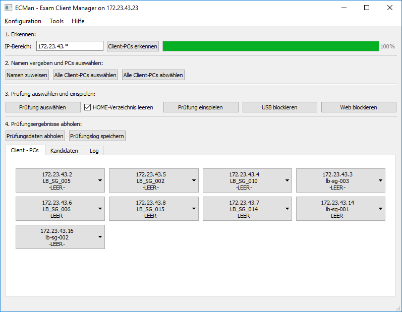

Nach dem Scan werden alle gefundenen Client-PCs automatisch ausgewählt (fette Schrift). Nicht benötigte PCs können per Klick auf die entsprechende Schaltfläche deaktiviert und heruntergefahren werden.

### Kandidatennamen vergeben

Vor dem Aufspielen der LB-Daten werden die Client-PCs benamt, um die Prüfungsergebnisse nacher den Kandidaten zuordnen zu können.

Die Zuweisung der Kandidatennamen zu den Client-PCs funktioniert, indem man die Namen (z.B. aus einer Excel-Liste) in das Kandidaten-Tab kopiert und danach die Schaltfläche *Kandidatennamen zuweisen* betätigt. *Alternativ zu den Namen können auch fortlaufende Ziffern vergeben werden. Die Kandidaten müssen dann* **ihre** *Ziffer auf die ausgedruckte Prüfung schreiben.*

Exisitierende Namenskonfigurationen werden überschrieben, wenn die entsprechende Checkbox ausgewählt ist. Eine Fehlermeldung reklamiert, wenn die Anzahl Namen nicht mit der Anzahl ausgewählter Client-PCs übereinstimmt.

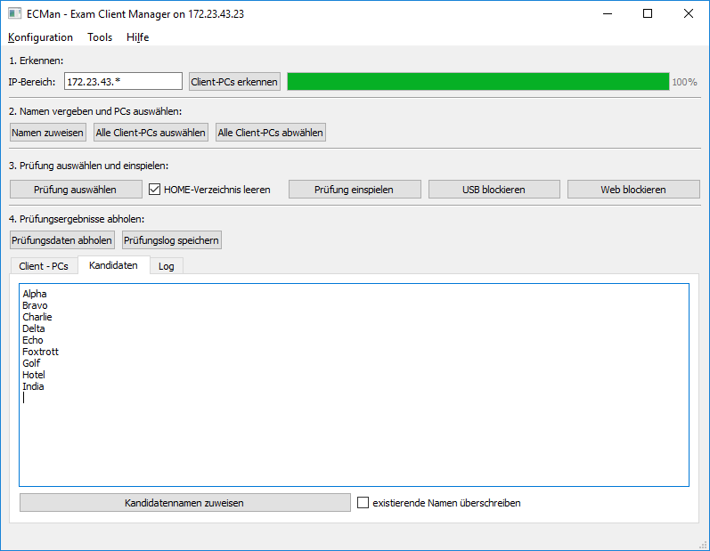

Die Reihenfolge der Zuordnung von PC und Kandidatennamen ist im Batch-Modus nicht steuerbar. Einzelne Kandidatennamen können über das Kontextmenü der LB-Clients gesetzt werden.

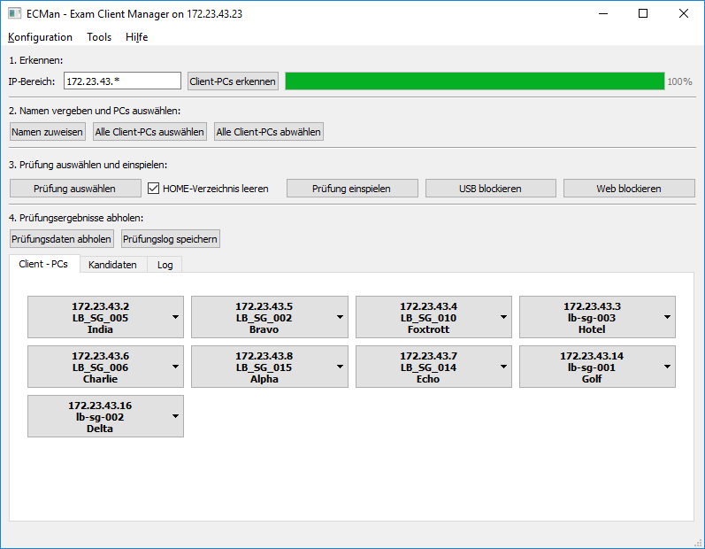

Das erfolgreiche Setzen der Kandidatennamen wird im ECMan-Hauptfenster angezeigt. Auf den Client-PCs werden die Kandidatennamen nach *Neustart* (siehe [*Weitere Features*](http://git-orca.hopto.org/sven/ECMan/wiki/Benutzerhinweise#neustart-bzw-herunterfahren-der-clients)) bzw. An- und Abmelden auf dem Login-Bildschirm angezeigt.

### Prüfung auswählen

Prüfungsdaten werden per Vorgabe von (versteckten) Netzwerk-Freigaben aufgespielt. Die Auswahl erfolgt nach *Prüfungs auswählen* mit dem unten abgebildeten Wizard.

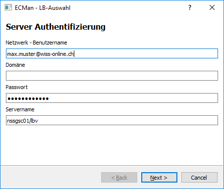

Nach korrekter Eingabe vom Benutzernamen und Passwort wird das gewünschte Prüfungsmodul auf der **linken Seite des Dialogs** ausgewählt:

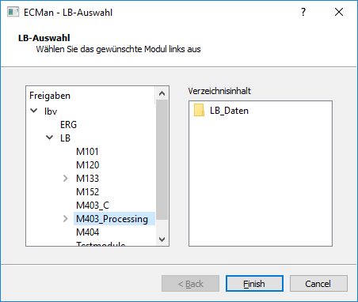

### Prüfung einspielen

Hier wird der eigentlich Kopierprozess für die ausgewählten Client-PCs gestartet. Ist alles korrekt verlaufen werden die Clients wie abgebildet **gelb** hinterlegt. Im Fehlerfall sind die Clients rot eingefärbt.

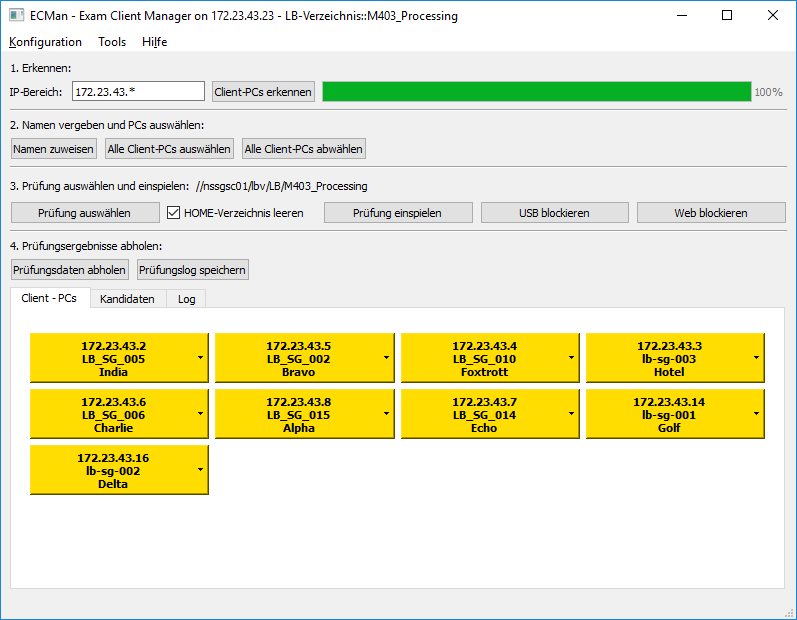

USB-Massenspeicher und Webzugriff wird - sofern nicht abgewählt - automatisch mit gesperrt. Mit beiden Optionen dauert der Einspielvorgang deutlich länger.

**Hinweis:** Nur bei aktivierter Checkbox *Home-Verzeichnis leeren* werden die Daten in allen regulären Benutzerordnern vor dem Kopieren der Prüfungsdaten gelöscht.

### Prüfungsdaten abholen

Prüfungsergebnisse werden per Vorgabe auf (versteckten) Netzwerk-Freigaben **für die jeweilige Klasse** gespeichert. Die Auswahl erfolgt nach *Prüfungs auswählen* mit dem unten abgebildeten Wizard.

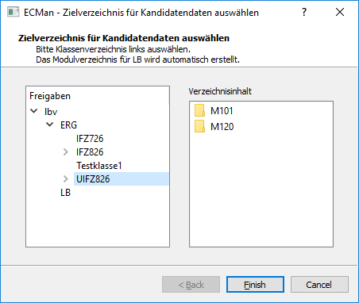

**Hinweis:** ECMan erstellt den zugehörigen Modulordner auf dem Ziellaufwerk selbst.

Nach Auswahl der Klasse (auf der **linken Seite des Dialogfensters**) beginnt der Kopierprozess. Alle Dateien vom Desktop der Clients werden zip-komprimiert gespeichert, solange Anzahl und Grösse der Dateien unterhalb der konfigurierten Grenzen liegt. Andernfalls wird nichts kopiert und ein Fehler ins Protokoll geschrieben.

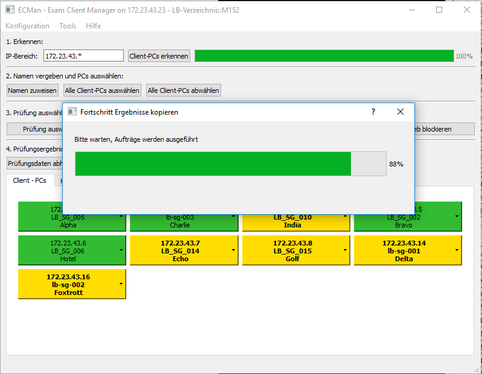

Erfolgreich abgearbeitete Clients werden im ECMan wie abgebildet **grün** hinterlegt, im Fehlerfall sind Sie **rot**.

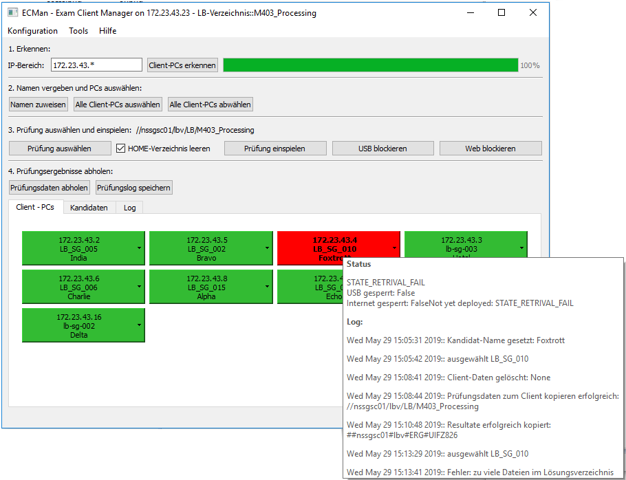

Bei Fehlern einzelner Clients lohnt sich ein Bick auf den dazugehörigen Tooltip. Dort finden sich detailierte Fehlermeldungen.

### Prüfungslog speichern

Diese Schaltfläche erstellt anhand der internen Programmprotokolle für jeden Client-PC ein PDF und legt dieses als *protokoll_datum_kandidatname.pdf* im gleichen Verzeichnis ab wie die Prüfungsergebnisse.

## Weitere Features

Die meisten oben beschriebenen Batch-Operationen sind auch für jeden Client einzeln durchführbar. Weiter Funktionen beinhalten:

### Neustart bzw. Herunterfahren der Clients

Client-PCs können gleichzeitig alle via Menüpunkt *Batch-Operationen -> Alle clients rebooten* oder einzeln via Kontext-Menü neu gestartet oder herunter gefahren werden. Dies geschieht ohne Rückfragen und ohne Rücksicht auf allfällige Datenverluste.

### Zurücksetzen der Clients

Der LB-Status aller Client-PCs kann via Menüpunkt *Batch-Operationen -> Alle Clients zurücksetzen* zurückgesetzt werden. Dabei werden keine Daten gelöscht. Für den Status-Reset einzelner Client-PCs wählen Sie den Menüpunkt "LB-Status zurücksetzen" auf der entsprechenden Client-PC Schaltfläche.

Der Inhalt der HOME-Verzeichnisse wird automatisch beim Kopieren der Prüfungsdaten gelöscht, wenn die Checkbox *HOME-Verzeichnis leeren* aktiviert ist. Dabei werden alle Nicht-Systemdateien in allen Nicht-Systemordnern des angegebenen Benutzers gelöscht. Dies geschieht ohne Rückfragen und ohne Rücksicht auf allfällige Datenverluste.

Die Daten einzelner PCs löschen Sie über den Menüpunkt *LB-Daten zurücksetzen* auf der entsprechenden Client-PC Schaltfläche.

### Ausführen einzelner Powershell-Befehle

Öffnen Sie die Remote-Powershell im Kontextmenü eines Client-PC. In der Remote-Powershell können einzelne Powershell-Kommandos an einzelne Client-PCs abgesetzt werden. Das oberse Textfeld enhält die bisher eingebenen Befehle und die Ausgaben bzw. Antworten des Cient-PCs. Im mittleren Feld können Powershell-Befehle eingegeben werden. In der unteren ComboBox finden Sie einfache Beispiel-Kommandos.

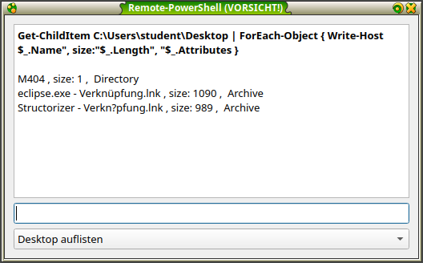

**Tip:** Erweitern Sie die Beispiel-Kommandos im der Datei *ps_samples.txt* in *scripts*-Ordner. Jede Zeile in dieser Datei enthält eine Kurzbeschreibung und den Befehl.

*Hilfe generiert am 12.07.2019*